# Reading In Data From Files

Mike LeVan

2025-02-07

We have seen a few different ways for us to store data. We discussed Vectors, Data Frames and Tibbles. We now move on to the question of how we can get data from a file into R so we can start some Elementary Data Analysis, Visualization, and other fun stuff!

## CSV Files

Let’s consider the case to where we have data in a CSV file. If you are unaware, CSV stands for “comma separated values.” These are simple text files where the data is separated by commas. We can use the `read.csv()` or `read_csv()`function to read the data into a variable in R.

A CSV file can be upload to RStudio by clicking on “File” and then “Import Dataset” button and selecting “From Text (base)” or “From Text (readr).”

[figure not shown]

For this particular example, I asked ChatGPT to create a CSV file for me using the following query :

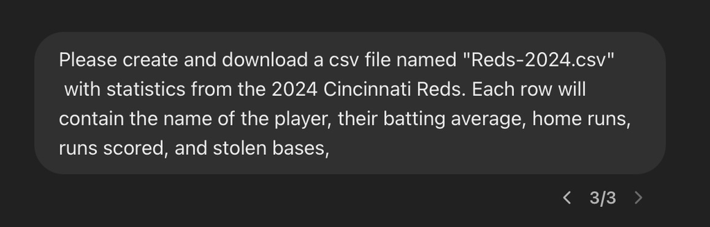

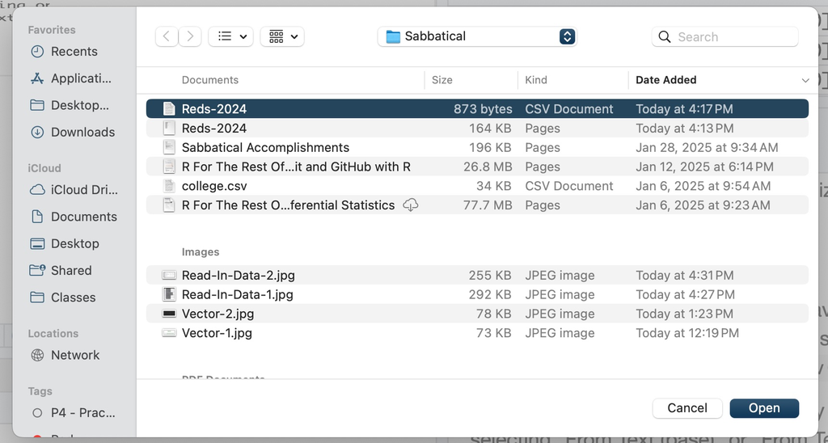

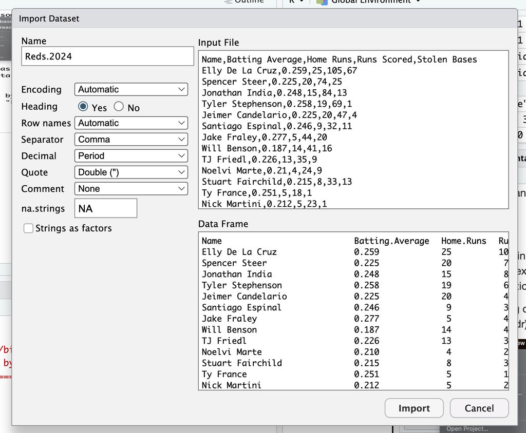

If you look in the upper left hand corner, you will see that you are given a choice for the name of your file. The default one given is `Reds.2024`, but you can change that to anything you wish. I went ahead and just kept this default name. I clicked on the “Import” button and the data was loaded into RStudio into the variable `Reds.2024`. You can look at the variable in the `Environment` tab :

[figure not shown]

You can also see the CSV file in the `Files` tab :

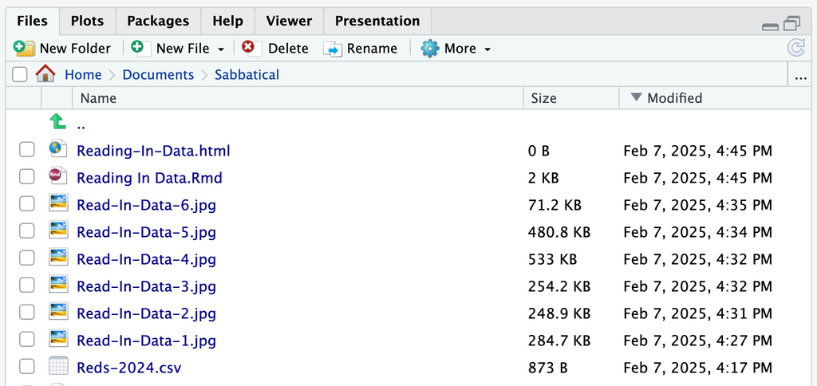

### read.csv( )

We can write part of our code to read in a CSV file using the `read.csv()` function. The `read.csv()` function takes in a file path as an argument. If you have a CSV file uploaded into the files section of RStudio, you can use the `read.csv()` function :

```r
# Read in the data

Reds2024_Another_Version <- read.csv("Reds-2024.csv")

# CAUTION : When creating variable names to use in your R script,
# make sure you use an underscore and not a dash. When R sees a dash,
# it can sometimes be interpreted as a minus sign and not a dash.
# This can cause errors in your code.

# You can try this by removing the comment tag below :

# Reds-2024 <- read.csv("Reds-2024.csv")
```

We can now see the new version of the data in the `Environment` tab :

[figure not shown]

`read.csv()` is a base R function. That means it is already loaded up when you start RStudio. You do not need to load any packages to use it.

However, there is a more powerful function called `read_csv()` that is part of the `readr` package. It can read in data faster and it can also read in data that is not in a CSV format, but we will stick with the CSV format for now.

### read_csv( )

One of the differences between read.csv( ) and read_csv( ) is that read_csv( ) is part of the `readr` package. This means you will need to load the `readr` package to use it. This is part of the `tidyverse` package. If you do not have tidyverse installed, make sure you go ahead and install it. Once tidyverse is install, you can load up the `readr` package.

If you are unsure if the `readr` package is loaded, you can look at the `Packages` tab in RStudio to see if the `readr` package is loaded. If it is not, you can load it by clicking on the checkbox next to the package name.

[figure not shown]

If needed, you can also put this into your script so the user will have it loaded up for them. You can load the `readr` package by using the `library()` function :

```r
# Load the readr package

library(readr)
```

You can now use the `read_csv()` function to read in the data :

```r
# Read in the data

Reds2024_Version_3 <- read_csv("Reds-2024.csv")
```

Why is read_csv better than read.csv? It is faster and it can read in data that is not in a CSV format. It can read in data that is in a TSV (Tab Separated Value) format, a DSV (Delimiter Separated Value) format, and a few others. It can also read in data that is in a fixed width format.

Basically, when in doubt, use `read_csv( )` instead of `read.csv( )`.

Now that we have the data loaded into R, we can start to do some Elementary Data Analysis. We can use all the commands we discussed when going over Vectors, Data Frames, and Tibbles.

```r
# Look at the data

head(Reds2024_Version_3)
```

```
## # A tibble: 6 × 5
##   Name              `Batting Average` `Home Runs` `Runs Scored` `Stolen Bases`
##   <chr>                         <dbl>       <dbl>         <dbl>          <dbl>
## 1 Elly De La Cruz               0.259          25           105             67
## 2 Spencer Steer                 0.225          20            74             25
## 3 Jonathan India                0.248          15            84             13
## 4 Tyler Stephenson              0.258          19            69              1
## 5 Jeimer Candelario             0.225          20            47              4
## 6 Santiago Espinal              0.246           9            32             11
```

```r
# Look at the structure of the data

class(Reds2024_Version_3)
```

```
## [1] "spec_tbl_df" "tbl_df"      "tbl"         "data.frame"
```

```r
# Look at the Stolen Bases category

Reds2024_Version_3$`Stolen Bases`
```

```
##  [1] 67 25 13  1  4 11 20 16  9  9 13  1  1  2  0  0  3  2  2  2  0  0  0  5  0
## [26]  0  1  0  0  0
```

### Using URL’s

You can also read in data from a URL. This is useful if you have a CSV file hosted on a website. You can use the `read.csv()` os `read_csv()` functions to read in the data from the URL.

If there is a direct URL to a CSV sheet, then you can use one of these commands to read in the data :

```r
# data_name <- read.csv('URL')

data1 <- read.csv('https://www.stats.govt.nz/assets/Uploads/Annual-enterprise-survey/Annual-enterprise-survey-2020-financial-year-provisional/Download-data/annual-enterprise-survey-2020-financial-year-provisional-csv.csv')

head(data1,2)
```

```
##   Year Industry_aggregation_NZSIOC Industry_code_NZSIOC Industry_name_NZSIOC
## 1 2020                     Level 1                99999       All industries
## 2 2020                     Level 1                99999       All industries
##                Units Variable_code
## 1 Dollars (millions)           H01
## 2 Dollars (millions)           H04
##                                     Variable_name     Variable_category   Value
## 1                                    Total income Financial performance 733,258
## 2 Sales, government funding, grants and subsidies Financial performance 660,630
##                                                                                             Industry_code_ANZSIC06
## 1 ANZSIC06 divisions A-S (excluding classes K6330, L6711, O7552, O760, O771, O772, S9540, S9601, S9602, and S9603)
## 2 ANZSIC06 divisions A-S (excluding classes K6330, L6711, O7552, O760, O771, O772, S9540, S9601, S9602, and S9603)
```

```r
# data_name <- read_csv('URL')
data2 <- read_csv('https://www.stats.govt.nz/assets/Uploads/Annual-enterprise-survey/Annual-enterprise-survey-2020-financial-year-provisional/Download-data/annual-enterprise-survey-2020-financial-year-provisional-csv.csv')
head(data2,2)
```

```
## # A tibble: 2 × 10
##    Year Industry_aggregation_N…¹ Industry_code_NZSIOC Industry_name_NZSIOC Units
##   <dbl> <chr>                    <chr>                <chr>                <chr>
## 1  2020 Level 1                  99999                All industries       Doll…
## 2  2020 Level 1                  99999                All industries       Doll…
## # ℹ abbreviated name: ¹Industry_aggregation_NZSIOC
## # ℹ 5 more variables: Variable_code <chr>, Variable_name <chr>,
## #   Variable_category <chr>, Value <chr>, Industry_code_ANZSIC06 <chr>
```

Note : As of now, there is not an easy way to read in data from a Google Drive. You can try to use the `googledrive` package, but for our purposes, if we have a csv file on Google Drive, we will download the file and upload it as we did earlier.

## Excel Files

We can also read in data from an Excel file. We can use the `readxl` package to read in the data. If you do not have the `readxl` package installed, you can install it by using the `install.packages()` function :

```r
# Install the readxl package

# install.packages("readxl")
```

You can then load the `readxl` package by using the `library()` function :

```r
# Load the readxl package

library(readxl)
```

You can then use the `read_excel()` function to read in the data :

```r
# Read in the data

data3 <- read_excel("Reds_1_Excel.xlsx")

head(data3,2)
```

```
## # A tibble: 2 × 5
##   Name            `Batting Average` `Home Runs` `Runs Scored` `Stolen Bases`
##   <chr>                       <dbl>       <dbl>         <dbl>          <dbl>
## 1 Elly De La Cruz             0.259          25           105             67
## 2 Spencer Steer               0.225          20            74             25
```

This allows to now carry out some EDA on the variable `data3`. For example, if we wanted to sum up the number of home runs hit by the Reds in 2024, we could use the following code :

```r
# Sum up the number of home runs hit by the Reds in 2024

sum(data3$`Home Runs`)
```

```
## [1] 174
```